Outras geometrias poderiam ser utlizadas, ao invés de pontos, poderíamos pedir uma geometria de linha por exemplo:

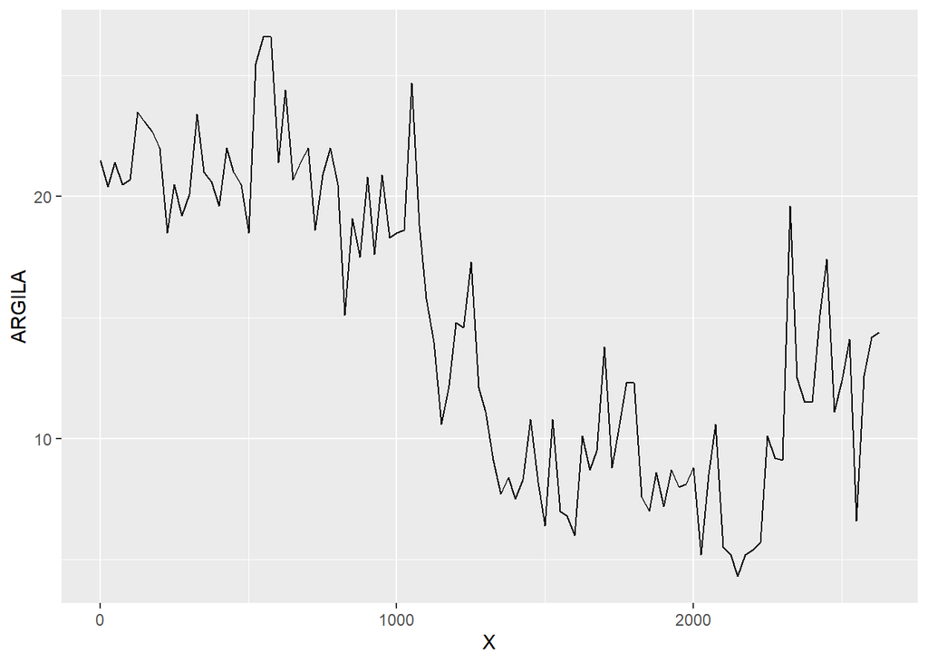

```r
geomorfologia %>%
  ggplot( aes(x=X, y =ARGILA) ) +
  geom_line()
```

Ou poderíamos mesclar as duas geometrias:

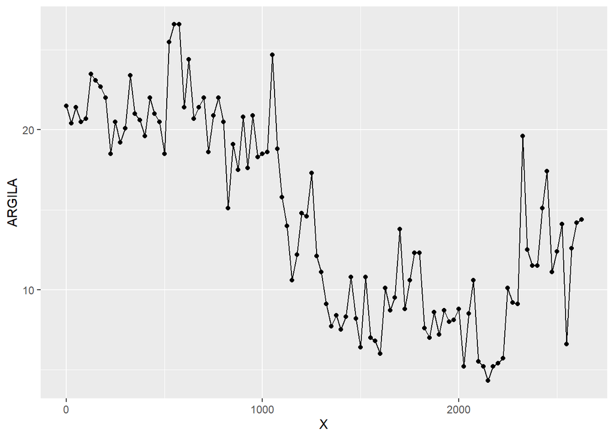

```r
geomorfologia %>%
  ggplot( aes(x=X, y =ARGILA) ) +
  geom_line()+
  geom_point()
```

Agora, finalmente, podemos controlar algumas propriedades dentro de cada geometria.

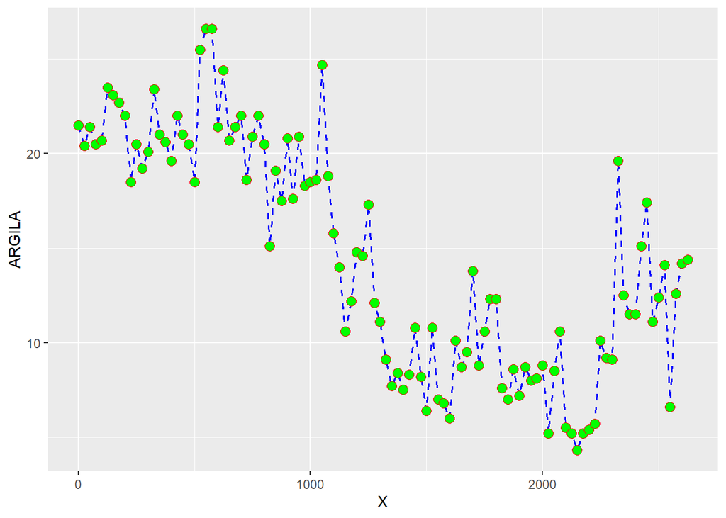

```r
geomorfologia %>%
  ggplot( aes(x=X, y =ARGILA) ) +
  geom_line(color="blue", # cor da linha
            lwd= 0.7, # espessura da linha
            linetype=2)+ # tipo de linha
  geom_point(shape=21, # tipo do marcador 0-14 são ocas de 15-18 sólidas e de 21-24 possuem borda e preenchimento
             fill="green", # cor do preenchimento do marcador
             color="red", # cor da borda do marcador
             size=3) # tamanho do marcador
```

**OBS**: A forma de um ponto (marcador) é controlada pelo argumento `shape`. Há algumas duplicadas aparentes nesse argumento, que recomendamos qua sejam testadas por exemplo, 0, 15 e 22 são quadrados. A diferença vem da interação das estéticas `color` e `fill`. As formas ocas são de 0 a 14 e a cor de sua borda é determinada por `color`, as formas sólidas são de 15 a 18 e a sua cor de preenchimento é definida por `color`, já as formas de 21 a 24 têm a cor de sua borda definida por `color` e a cor de seu preenchimento definida por `fill`. Veja os exemplos:

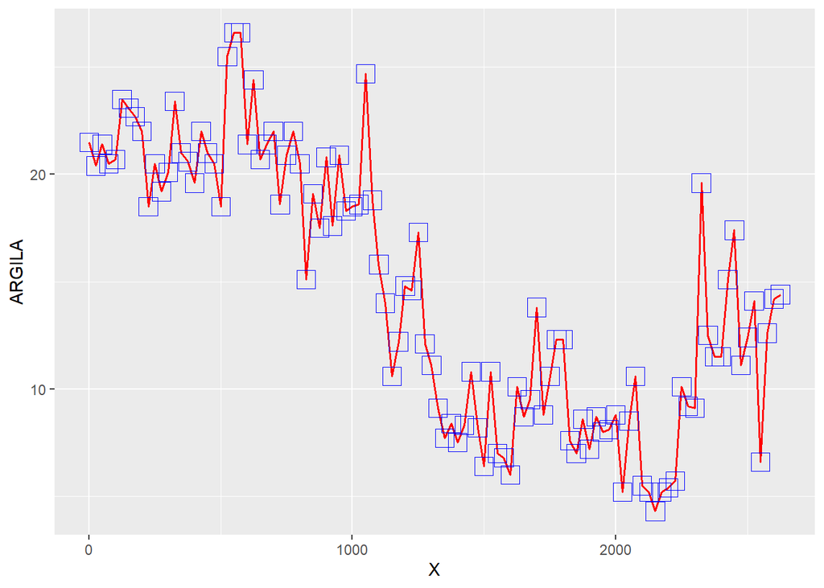

```r
geomorfologia %>%
  ggplot( aes(x=X, y =ARGILA) ) +
  geom_line(color="red", lwd= 0.7, linetype=1) +
  geom_point(shape=0, size=5, color = "blue")
```

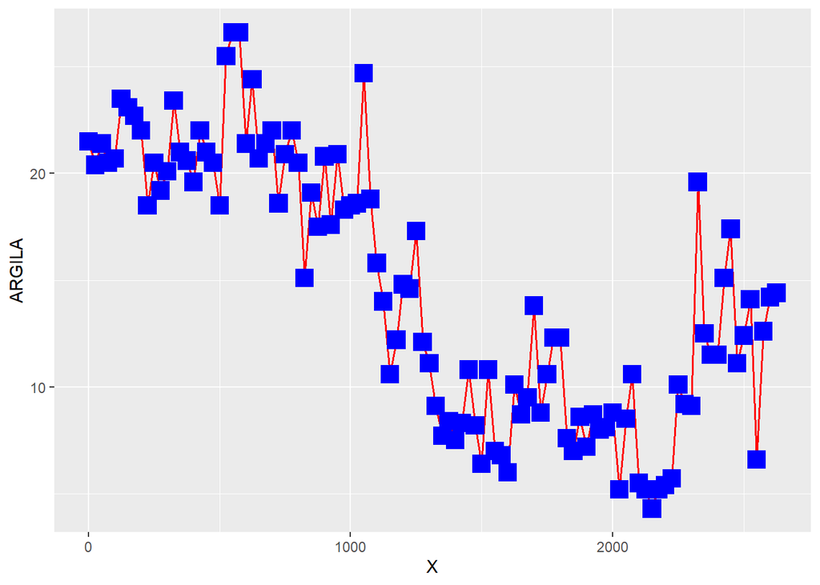

```r
geomorfologia %>%
  ggplot( aes(x=X, y =ARGILA) ) +
  geom_line(color="red", lwd= 0.7, linetype=1) +
  geom_point(shape=15, size=5, color = "blue")
```

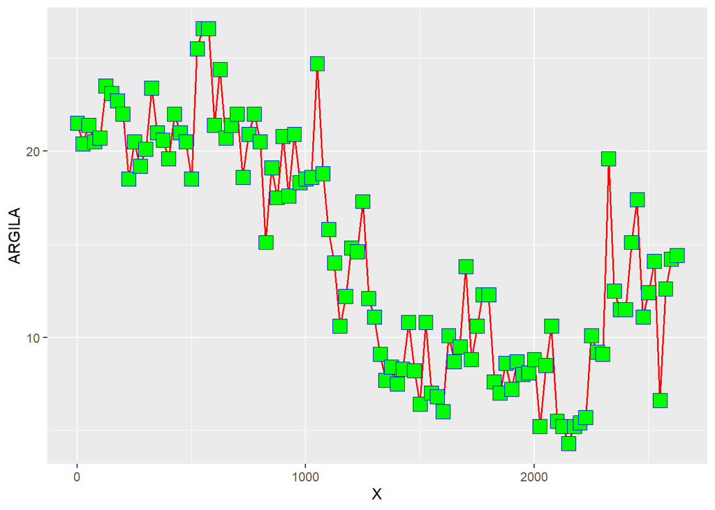

```r
geomorfologia %>%
  ggplot( aes(x=X, y =ARGILA) ) +
  geom_line(color="red", lwd= 0.7, linetype=1) +
  geom_point(shape=22, size=5, color = "blue", fill="green")
```

Nosso próximo passo será controlar os títulos dos eixos a partir da função `labs()`.

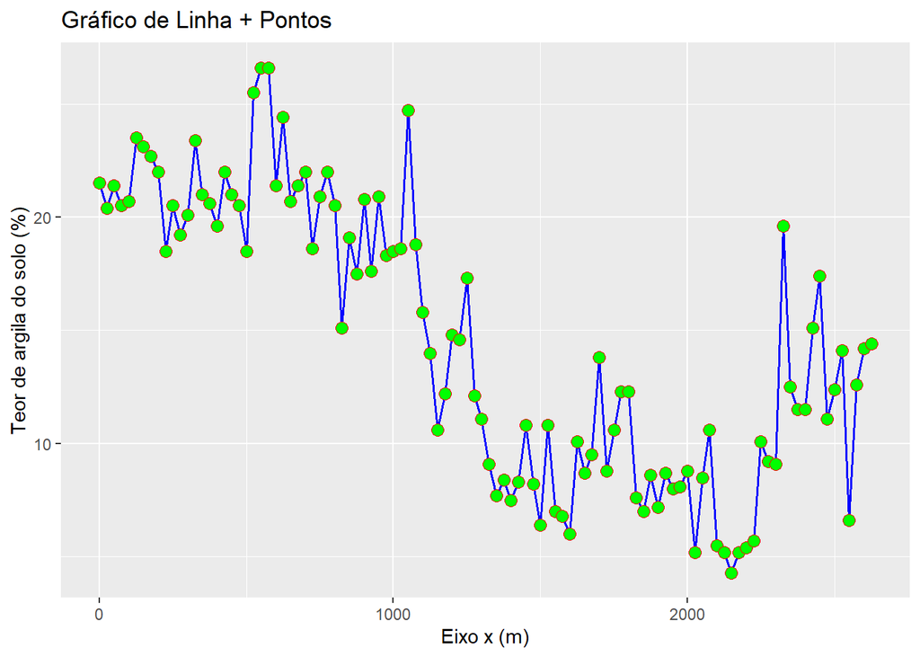

```r
geomorfologia %>%
  ggplot( aes(x=X, y =ARGILA) ) +
  geom_line(col="blue", lwd= 0.7, lty=1)+
  geom_point(shape=21, fill="green", col="red", size=3) +
  labs(x="Eixo x (m)",y="Teor de argila do solo (%)", title = "Gráfico de Linha + Pontos")
```